# Informe hito 1

@saguerraty @BastyZ @AnnBenavides

August 25, 2019

## Introducción

En este proyecto se analiza información diaria de mediciones de calidad del aire en Parque O’Higgins, así como temperaturas y precipitaciones en Quinta Normal. Estas mediciones fueron tomadas por SINCA del Ministerio del Medio Ambiente y el CR^2 (Center for Climate and Resilience Research) respectivamente e incluyen datos obtenidos desde 1997 hasta la fecha en ambas estaciones.

Se busca utilizar los datos para buscar relacion entre la calidad del aire y temperatura/precipitaciones, buscar patrones estacionales las caracteristicas observables del aire (particularmente tendencia anual), y buscar ver la influencia de leyes y restricciones ambientales como la restricción vehicular a cataliticos anteriores a 2012.

## Descripción de datos y exploración

Se extrajo datos de del Sistema de Información Nacional de Calidad del Aire (SINCA) y Center for Climate an Resilence Research (CR2), para mediciones diarias de la calidad del aire e historial climático respectivamente.

### CR2: Foco Quinta Normal

Se obtiene información histórica diaria de la temperatura media (°C), temperatura máxima(°C) y precipitaciones(mm) en la estación de medición de Quinta Normal (la mas cercana a Parque O’higgins) desde 1950 a la fecha.

## Hipótesis

Inicialmente nos planteamos las siguientes dudas planteadas a modo de afirmaciones, las cuales intentaremos responder afirmativamente o refutandola durante la exploración y análisis de los datos.

- Existe una correlación entre la calidad del aire y las condiciones climáticas (temperatura/precipitaciones).
- Existen patrones estacionales en las condiciones del aire, y han evolucionado con los años.
- Existe influencia real de las leyes y restricciones en la calidad del aire en Santiago.
- Existe una relación entre temperaturas máximas y mediciones de Ozono.

El enfoque inicial es analizar los histogramas y series de tiempo para comprender como se distribuyen los datos, para luego cruzarlos y buscar correlaciones que apoyen o refuten nuestras hipotesis. En el caso de los patrones se considera analizar la variaciones de cada medida durante los años respecto al año anterior, tanto de forma agregada como variación diaria/mensual.

## Manejo y exploración de datos

Se relacionan todos los datos anteriores respecto con su fechas, para su manejo más afable. Se recuerda que no todas la mediciones tienen registros desde el inicio de la toma de muestras, siendo el rango 2009-2017 el que contiene la mayor completitud.

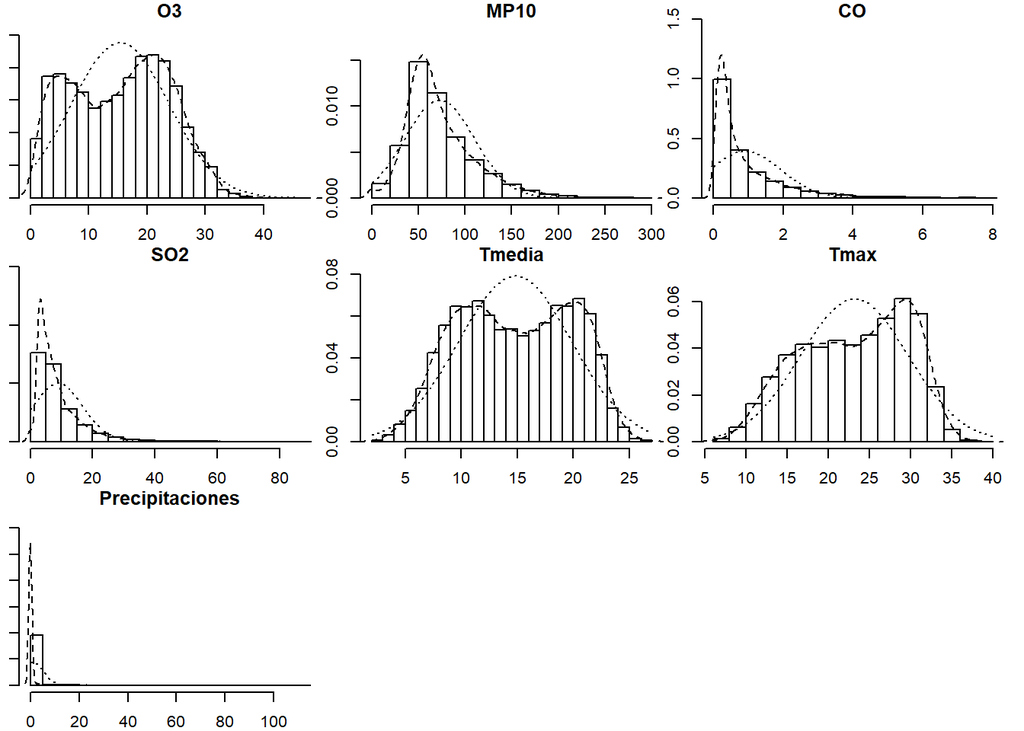

```r
datos<-subset(datos,select = -c(MP25,NO2))
multi.hist(datos[,c(5:11)])
```

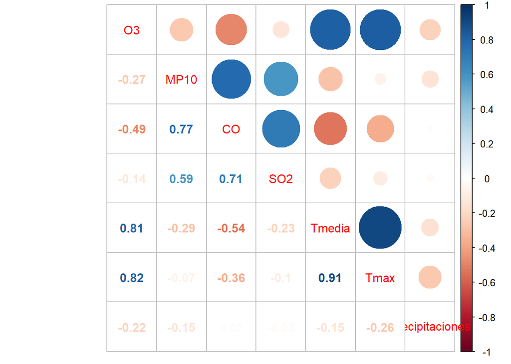

```r
correlaciones=cor(datos[,c(5:11)], use = "complete.obs")
corrplot.mixed(correlaciones,upper = "circle" )
```

### Tendencias mensuales

Para evaluar de manera rápida la evolución de las métricas a través de los años, se genera una agregación por año y mes, y se grafican para observar los cambios y patrones más notorios:

```r
data_monthly<-subset(datos, select= -c(1,4,12))
monthly_data<-aggregate(data_monthly[3:9], by=list(anno=data_monthly$anno, mes=data_monthly$mes), FUN = mean)
```

- *Enero*

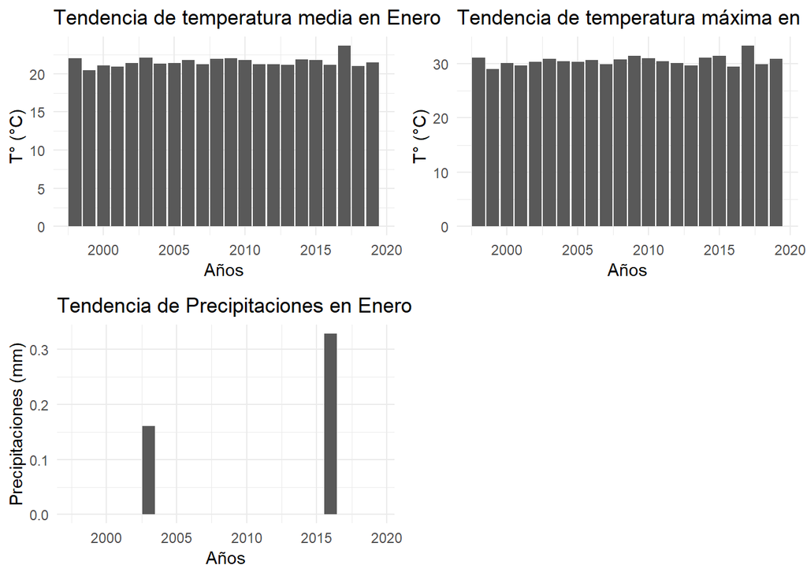

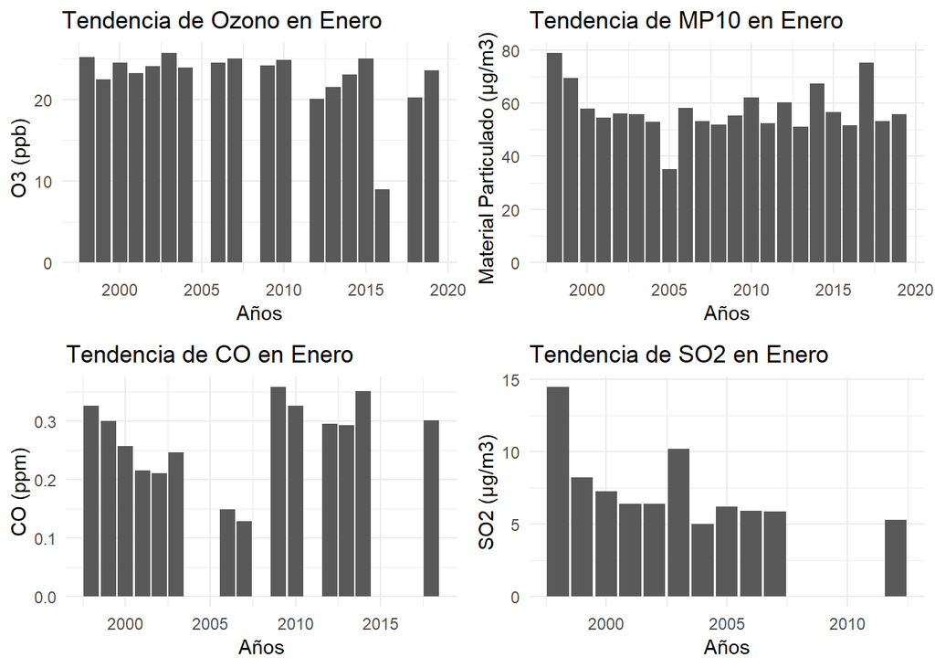